# team_data_notebook

```python
import pandas as pd
import numpy as np
from sklearn import model_selection
from sklearn.metrics import accuracy_score, confusion_matrix, ConfusionMatrixDisplay, classification_report
from sklearn.linear_model import LogisticRegression
import xgboost as xgb
import warnings
import matplotlib.pyplot as plt
from sklearn.model_selection import train_test_split, GridSearchCV, learning_curve
from sklearn.ensemble import GradientBoostingClassifier
from sklearn.utils.class_weight import compute_class_weight
from sklearn.impute import SimpleImputer
from sklearn.decomposition import PCA
from sklearn.preprocessing import StandardScaler
from sklearn.neighbors import KNeighborsClassifier
from xgboost import XGBClassifier, plot_importance
import lightgbm as lgb
from sklearn.ensemble import StackingClassifier
from sklearn.ensemble import RandomForestClassifier
import tensorflow as tf
from tensorflow.keras.callbacks import EarlyStopping, ReduceLROnPlateau
from catboost import CatBoostClassifier
import optuna
from sklearn.model_selection import StratifiedKFold

warnings.filterwarnings('ignore')
```

## Read Train data

```python
file_path = "C:/Users/samar/OneDrive/Desktop/mathapp/APST/dataChallenge"
train_home_team_statistics_df = pd.read_csv(file_path + "/Train_Data/train_home_team_statistics_df.csv", index_col=0)
train_away_team_statistics_df = pd.read_csv(file_path + "/Train_Data/train_away_team_statistics_df.csv", index_col=0)

train_scores = pd.read_csv(file_path + "/Y_train.csv", index_col=0)

train_home = train_home_team_statistics_df.iloc[:,2:]
train_away = train_away_team_statistics_df.iloc[:,2:]

train_home.columns = 'HOME_' + train_home.columns
train_away.columns = 'AWAY_' + train_away.columns

train_data =  pd.concat([train_home,train_away],join='inner',axis=1)
train_scores = train_scores.loc[train_data.index]

train_data = train_data.replace({np.inf:np.nan,-np.inf:np.nan})
```

## Analyse des données

```python
print('dimension of the dataset:', train_home.shape)
print()
train_home.info()
```

[output not shown]

```python
print('dimension of the dataset:', train_away.shape)
print()
train_away.info()
```

```
dimension of the dataset: (12303, 140)

<class 'pandas.core.frame.DataFrame'>
Index: 12303 entries, 0 to 12302
Columns: 140 entries, AWAY_TEAM_SHOTS_TOTAL_season_sum to AWAY_TEAM_GOALS_5_last_match_std
dtypes: float64(140)
memory usage: 13.2 MB
```

```python
print('dimension of the dataset:', train_data.shape)
print()
train_data.info()
```

```
dimension of the dataset: (12303, 280)

<class 'pandas.core.frame.DataFrame'>
Index: 12303 entries, 0 to 12302
Columns: 280 entries, HOME_TEAM_SHOTS_TOTAL_season_sum to AWAY_TEAM_GOALS_5_last_match_std
dtypes: float64(280)
memory usage: 26.6 MB
```

#### Analyse des données manquantes

En analysant les données manquantes sur les colonnes, on voit que la colonne avec le plus de données manquantes a un percentage de 27% de données manquantes

```python
column_missing_values = train_data.isna().mean().sort_values(ascending=False)
column_missing_values
```

```
HOME_TEAM_INJURIES_5_last_match_std                 0.269690
AWAY_TEAM_INJURIES_5_last_match_std                 0.269284
AWAY_TEAM_INJURIES_5_last_match_sum                 0.238397
HOME_TEAM_INJURIES_5_last_match_sum                 0.238316
AWAY_TEAM_INJURIES_5_last_match_average             0.238316
                                                      ...
AWAY_TEAM_DANGEROUS_ATTACKS_5_last_match_average    0.000000
AWAY_TEAM_ATTACKS_5_last_match_sum                  0.000000
AWAY_TEAM_ATTACKS_season_std                        0.000000
HOME_TEAM_CORNERS_5_last_match_std                  0.000000
AWAY_TEAM_SHOTS_OFF_TARGET_5_last_match_sum         0.000000
Length: 280, dtype: float64
```

```python
print(f'Percentage de colonnes avec de données manquantes: {len(column_missing_values[column_missing_values > 0])*100/len(column_missing_values):.3f} %')
```

```
Percentage de colonnes avec de données manquantes: 84.286 %
```

En analysant sur les lignes, on voit qu'on a des lignes avec beaucoup de données manquantes (> 50%)

```python
row_missing_values = train_data.isna().mean(axis=1).sort_values(ascending=False)
row_missing_values
```

```
ID
10163    0.557143
5646     0.557143
4624     0.442857
8538     0.435714
835      0.435714
           ...
4907     0.000000
4908     0.000000
4909     0.000000
4911     0.000000
12302    0.000000
Length: 12303, dtype: float64
```

```python
print(f'Percentage de lignes avec de données manquantes: {len(row_missing_values[row_missing_values > 0])*100/len(row_missing_values):.3f} %')
```

```
Percentage de lignes avec de données manquantes: 32.838 %
```

On ne va pas enlever des lignes/colonnes pour ne pas prendre le risque de perdre des informations avec cette opération

Comme la colonne avec le plus de données manquantes a environ 27% de données manquantes, on va performer une imputation des données

On considère qu'on va avoir suffisament des données pour faire cette imputation sans inserer beaucoup de biais

On va faire ça au moment de réaliser l'entraînement

## Entraînement de modèles

```python
# Targets
train_scores['TARGET'] = train_scores[['HOME_WINS', 'DRAW', 'AWAY_WINS']].idxmax(axis=1)
target_mapping = {'HOME_WINS': 0, 'DRAW': 1, 'AWAY_WINS': 2}
train_scores['TARGET'] = train_scores['TARGET'].map(target_mapping)

# Split Data
X_train, X_test, y_train, y_test = train_test_split(
    train_data, train_scores['TARGET'], test_size=0.2, random_state=42
)
```

```python
train_scores.head()
```

| ID | HOME_WINS | DRAW | AWAY_WINS | TARGET |
| --- | --- | --- | --- | --- |
| 0 | 0 | 0 | 1 | 2 |
| 1 | 0 | 1 | 0 | 1 |
| 2 | 0 | 0 | 1 | 2 |
| 3 | 1 | 0 | 0 | 0 |
| 4 | 0 | 1 | 0 | 1 |

```python
print(f"Nombre de données d'entrainement: {X_train.shape[0]}")
print(f"Nombre de données de test: {X_test.shape[0]}")
```

```
Nombre de données d'entrainement: 9842
Nombre de données de test: 2461
```

```python
# Class Weights
class_weights = compute_class_weight('balanced', classes=np.unique(y_train), y=y_train)
class_weights_dict = {i: weight for i, weight in enumerate(class_weights)}
```

```python
class_weights_dict
```

```
{0: 0.7677665964583821, 1: 1.2785138997142116, 2: 1.0924630924630925}
```

```
Confusion Matrix:
 [[4273    0    0]
 [   0 2566    0]
 [   0    0 3003]]
```

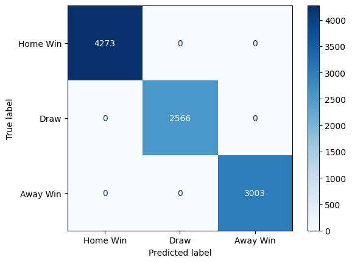

```python
from sklearn.metrics import confusion_matrix, ConfusionMatrixDisplay
import matplotlib.pyplot as plt

# Get the confusion matrix
cm = confusion_matrix(y_train, y_train)  # Use your predictions here (e.g., y_pred from ensemble)

# Print the confusion matrix
print("Confusion Matrix:\n", cm)

# Optional: Visualize the confusion matrix
disp = ConfusionMatrixDisplay(confusion_matrix=cm, display_labels=['Home Win', 'Draw', 'Away Win'])
disp.plot(cmap=plt.cm.Blues)
plt.show()
```

### Imputation et standardisation des données

```python
imputer = SimpleImputer(strategy='median')
X_train_imp = imputer.fit_transform(X_train)

scaler = StandardScaler()
X_train_scaled = scaler.fit_transform(X_train_imp)
```

## Gradient Boosting Model

```python
params1 = {
    'n_estimators': 200,
    'learning_rate': 0.01,
    'max_depth': 5,
    'subsample': 0.9,
    'random_state': 42
}
gb_model = GradientBoostingClassifier(**params1)
gb_model.fit(X_train_scaled, y_train)
y_pred = gb_model.predict(X_test)
print("Accuracy:", accuracy_score(y_test, y_pred))
```

```
Accuracy: 0.4034945144250305
```

```python
# Model and Hyperparameter Tuning to improve the model
params = {
    'n_estimators': [100],
    'learning_rate': [0.01],
    'max_depth': [5],
    'subsample': [ 0.9]
}

gb_model = GradientBoostingClassifier(random_state=42)
grid_search = GridSearchCV(
    gb_model, param_grid=params, scoring='accuracy', cv=3, verbose=1, n_jobs=-1
)
grid_search.fit(X_train_scaled, y_train)

# Evaluate Model
best_model_gb = grid_search.best_estimator_
best_model_gb_accuracy = y_pred = best_model_gb.predict(X_test)
best_model_gb_accuracy = accuracy_score(y_test, y_pred)

print("Best Parameters:", grid_search.best_params_)
print("Accuracy:", accuracy_score(y_test, y_pred))
print("Classification Report:\n", classification_report(y_test, y_pred))
```

```
Fitting 3 folds for each of 1 candidates, totalling 3 fits
Best Parameters: {'learning_rate': 0.01, 'max_depth': 5, 'n_estimators': 100, 'subsample': 0.9}
Accuracy: 0.4559122308004876
Classification Report:
               precision    recall  f1-score   support

           0       0.46      0.95      0.62      1083
           1       0.20      0.01      0.02       620
           2       0.48      0.11      0.18       758

    accuracy                           0.46      2461
   macro avg       0.38      0.36      0.28      2461
weighted avg       0.40      0.46      0.33      2461
```

```python
y_pred = best_model_gb.predict(X_test)
```

```python
# Feature Importance
importances = best_model_gb.feature_importances_
feature_names = X_train.columns
feature_importance = pd.DataFrame({'Feature': feature_names, 'Importance': importances})
feature_importance = feature_importance.sort_values(by='Importance', ascending=False).head(25)
print("Top 10 Features:\n", feature_importance)
```

```
Top 10 Features:
                                                Feature  Importance
173           AWAY_TEAM_BALL_POSSESSION_season_average    0.058256
23                HOME_TEAM_SHOTS_TOTAL_season_average    0.039347
3                 HOME_TEAM_SHOTS_ON_TARGET_season_sum    0.032468
45                   HOME_TEAM_GAME_WON_season_average    0.031393
160                      AWAY_TEAM_GAME_WON_season_sum    0.030662
33            HOME_TEAM_BALL_POSSESSION_season_average    0.026542
22                      HOME_TEAM_GAME_LOST_season_sum    0.022766
187                 AWAY_TEAM_GAME_LOST_season_average    0.021945
42          HOME_TEAM_DANGEROUS_ATTACKS_season_average    0.019978
162                     AWAY_TEAM_GAME_LOST_season_sum    0.017289
47                  HOME_TEAM_GAME_LOST_season_average    0.016797
26            HOME_TEAM_SHOTS_ON_TARGET_season_average    0.016308
143               AWAY_TEAM_SHOTS_ON_TARGET_season_sum    0.015695
17              HOME_TEAM_DANGEROUS_ATTACKS_season_sum    0.014847
185                  AWAY_TEAM_GAME_WON_season_average    0.013754
20                       HOME_TEAM_GAME_WON_season_sum    0.013476
211         AWAY_TEAM_SHOTS_INSIDEBOX_5_last_match_sum    0.011860
178                   AWAY_TEAM_ATTACKS_season_average    0.011721
170  AWAY_TEAM_SUCCESSFUL_PASSES_PERCENTAGE_season_...    0.011212
24            HOME_TEAM_SHOTS_INSIDEBOX_season_average    0.010046
182         AWAY_TEAM_DANGEROUS_ATTACKS_season_average    0.009946
168                    AWAY_TEAM_PASSES_season_average    0.009745
166           AWAY_TEAM_SHOTS_ON_TARGET_season_average    0.009161
163               AWAY_TEAM_SHOTS_TOTAL_season_average    0.008779
243     AWAY_TEAM_BALL_POSSESSION_5_last_match_average    0.007483
```

[figure not shown]

```python
max_num_features = 25
top_features = feature_importance.head(max_num_features)

plt.figure(figsize=(10, 10))
plt.barh(top_features['Feature'], top_features['Importance'])
plt.xlabel('Importance')
plt.ylabel('Features')
plt.title(f'Top {max_num_features} Most Important Features in Random Forest')
plt.gca().invert_yaxis()
plt.tight_layout()
plt.show()
```

```python
#using class weight to try to improve the model
params1 = {
    'n_estimators': 200,
    'learning_rate': 0.01,
    'max_depth': 5,
    'subsample': 0.9,
    'random_state': 42
}
gb_model = GradientBoostingClassifier(**params1)

sample_weights = [class_weights_dict[label] for label in y_train]
gb_model.fit(X_train_scaled, y_train, sample_weight=sample_weights)

# Evaluate
y_pred = gb_model.predict(X_test)
accuracy = accuracy_score(y_test, y_pred)
print("Accuracy with class weights:", accuracy)
```

```
Accuracy with class weights: 0.45388053636733033
```

Using class weights can decrease accuracy if the adjustment overemphasizes minority classes, leading the model to misclassify majority class instances more often. This happens because class weights effectively alter the loss function, penalizing errors in the minority class more heavily.

This is useful for imbalanced datasets where minority classes are underrepresented, but if the dataset is not highly imbalanced, the re-weighting can disrupt the model's balance, reducing its ability to generalize effectively.

```python
n_features = X_train_scaled.shape[1]
total_pairs = n_features * (n_features - 1) // 2

correlation_matrix = X_train_scaled.corr()
high_corr_pairs = np.sum(np.triu(correlation_matrix > 0.9, k=1))

percentage_high_corr = (high_corr_pairs / total_pairs) * 100

print(f"Nombre total de paires: {total_pairs}")
print(f"Nombre de paires avec une corrélation > 0,9: {high_corr_pairs}")
print(f"Pourcentage de paires fortement corrélées: {percentage_high_corr:.2f}%")
```

```
Nombre total de paires: 39060
Nombre de paires avec une corrélation > 0,9: 112
Pourcentage de paires fortement corrélées: 0.29%
```

L'analyse de corrélation montre que les caractéristiques sont faiblement corrélées, indiquant que la variance est répartie sur de nombreuses variables. Pour confirmer cette observation et/ou évaluer une éventuelle réduction de la dimensionnalité du jeu de données, j'applique une analyse en composantes principales (PCA) afin de déterminer le nombre de composantes nécessaires pour expliquer 95% de la variance.

```python
pca = PCA(n_components=0.95)
X_train_pca = pca.fit_transform(X_train)
X_test_pca = pca.transform(X_test)

print(f"Nombre de composantes principales: {X_train_pca.shape[1]}")
```

```
Nombre de composantes principales: 125
```

Le nombre de composantes principales nécessaires pour expliquer la variance est élevé, confirmant les résultats de l'analyse de corrélation: presque aucune caractéristique n'est redondante. Pour réduire davantage la dimensionnalité, je sélectionne et entraîne le modèle en utilisant uniquement les caractéristiques ayant une importance supérieure à 0,3%.

```python
threshold = 0.003
important_features = feature_importance[feature_importance['Importance'] > threshold]

print(f"Nombre de features sélectionnées: {len(important_features)}")

selected_features_gb = important_features['Feature'].tolist()

X_train_selected = X_train_scaled[selected_features_gb]
X_test_selected = X_test[selected_features_gb]
```

```
Nombre de features sélectionnées: 25
```

```python
params = {
    'n_estimators': 200,
    'learning_rate': 0.01,
    'max_depth': 5,
    'subsample': 0.9,
    'random_state': 42
}
gb_model_selected = GradientBoostingClassifier(**params)
gb_model_selected.fit(X_train_selected, y_train)
y_pred = gb_model_selected.predict(X_test_selected)
```

```python
y_pred_selected = gb_model_selected.predict(X_test_selected)
score_gb_selected = accuracy_score(y_test, y_pred_selected)
score_gb_selected
```

```
0.49451442503047544
```

## Random Forest

```python
# Initialize Random Forest with hyperparameters
rf_model = RandomForestClassifier(
    n_estimators=300,
    max_depth=12,
    min_samples_split=5,
    random_state=42,
    class_weight='balanced'
)

# Train the model
rf_model.fit(X_train_scaled, y_train)

# Predict on validation data
y_pred_rf = rf_model.predict(X_test)

# Evaluate
rf_accuracy = accuracy_score(y_test, y_pred_rf)
print("Random Forest Accuracy:", rf_accuracy)
```

```
Random Forest Accuracy: 0.4746038195855343
```

```python
# Hyperparameter grid
param_grid = {
    'n_estimators': [100, 200, 300],
    'max_depth': [8, 12, 16],
    'min_samples_split': [2, 5, 10],
    'class_weight': ['balanced', 'balanced_subsample']
}

# Initialize Random Forest and Grid Search
rf = RandomForestClassifier(random_state=42)
grid_search = GridSearchCV(
    estimator=rf, param_grid=param_grid, cv=3, scoring='accuracy', n_jobs=-1
)

# Fit the model
grid_search.fit(X_train_scaled, y_train)

# Best parameters
best_rf = grid_search.best_estimator_
print("Best Parameters:", grid_search.best_params_)

# Predictions
y_train_pred = best_rf.predict(X_train_scaled)
y_test_pred = best_rf.predict(X_test)

# Evaluate
rf_best_model_accuracy = accuracy_score(y_test, y_test_pred)

print("best model Accuracy:", rf_best_model_accuracy)
print("\nClassification Report:\n", classification_report(y_test, y_test_pred))

# Feature importance
feature_importances = pd.DataFrame({
    'Feature': train_data.columns,
    'Importance': best_rf.feature_importances_
}).sort_values(by='Importance', ascending=False)

print("\nTop Features:\n", feature_importances.head(25))
```

```
Best Parameters: {'class_weight': 'balanced_subsample', 'max_depth': 16, 'min_samples_split': 2, 'n_estimators': 300}
best model Accuracy: 0.48720032507110933

Classification Report:
               precision    recall  f1-score   support

           0       0.50      0.80      0.62      1083
           1       0.25      0.03      0.06       620
           2       0.48      0.41      0.44       758

    accuracy                           0.49      2461
   macro avg       0.41      0.41      0.37      2461
weighted avg       0.43      0.49      0.42      2461


Top Features:
                                         Feature  Importance
22               HOME_TEAM_GAME_LOST_season_sum    0.005336
20                HOME_TEAM_GAME_WON_season_sum    0.005177
47           HOME_TEAM_GAME_LOST_season_average    0.005169
45            HOME_TEAM_GAME_WON_season_average    0.005135
160               AWAY_TEAM_GAME_WON_season_sum    0.005051
162              AWAY_TEAM_GAME_LOST_season_sum    0.005011
23         HOME_TEAM_SHOTS_TOTAL_season_average    0.004986
173    AWAY_TEAM_BALL_POSSESSION_season_average    0.004911
17       HOME_TEAM_DANGEROUS_ATTACKS_season_sum    0.004739
33     HOME_TEAM_BALL_POSSESSION_season_average    0.004736
187          AWAY_TEAM_GAME_LOST_season_average    0.004734
185           AWAY_TEAM_GAME_WON_season_average    0.004696
3          HOME_TEAM_SHOTS_ON_TARGET_season_sum    0.004619
166    AWAY_TEAM_SHOTS_ON_TARGET_season_average    0.004490
42   HOME_TEAM_DANGEROUS_ATTACKS_season_average    0.004478
19                   HOME_TEAM_GOALS_season_sum    0.004457
26     HOME_TEAM_SHOTS_ON_TARGET_season_average    0.004431
143        AWAY_TEAM_SHOTS_ON_TARGET_season_sum    0.004341
153                AWAY_TEAM_ATTACKS_season_sum    0.004281
38             HOME_TEAM_ATTACKS_season_average    0.004275
57                 HOME_TEAM_CORNERS_season_std    0.004262
44               HOME_TEAM_GOALS_season_average    0.004262
159                  AWAY_TEAM_GOALS_season_sum    0.004261
178            AWAY_TEAM_ATTACKS_season_average    0.004261
60             HOME_TEAM_YELLOWCARDS_season_std    0.004252
```

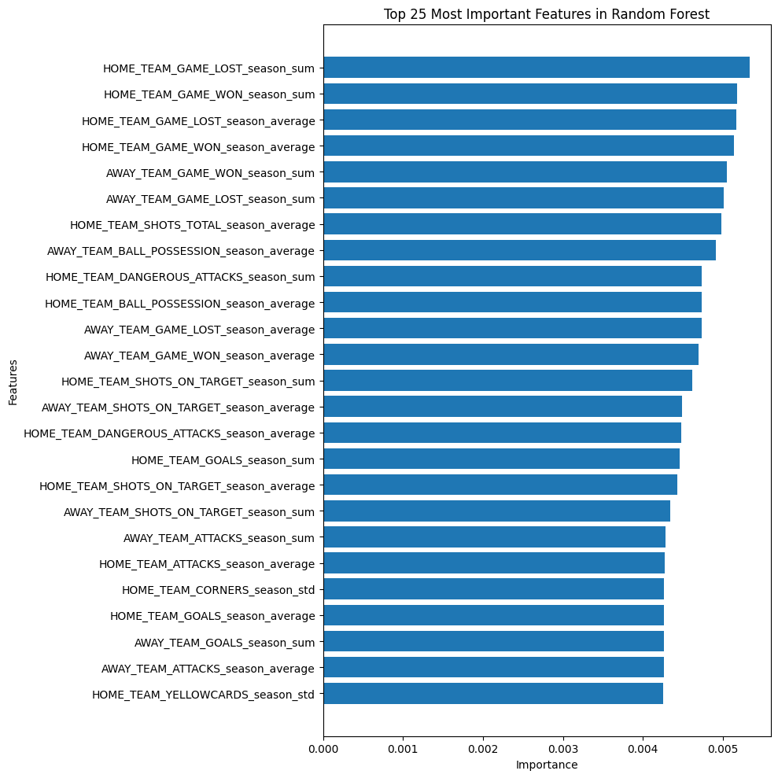

```python
max_num_features = 25
top_features = feature_importances.head(max_num_features)
plt.figure(figsize=(10, 10))
plt.barh(top_features['Feature'], top_features['Importance'])
plt.xlabel('Importance')
plt.ylabel('Features')
plt.title(f'Top 25 Most Important Features in Random Forest')
plt.gca().invert_yaxis()
plt.tight_layout()
plt.show()
```

Bien que aucune caractéristique ne soit dominante (elles ont toutes une importance inférieure à 1 %), certaines pourraient contenir des informations similaires. Pour identifier d'éventuelles redondances et simplifier le modèle, une analyse de corrélation entre les caractéristiques est réalisée.

```python
n_features = X_train_scaled.shape[1]
total_pairs = n_features * (n_features - 1) // 2

correlation_matrix = X_train_scaled.corr()
high_corr_pairs = np.sum(np.triu(correlation_matrix > 0.9, k=1))

percentage_high_corr = (high_corr_pairs / total_pairs) * 100

print(f"Nombre total de paires: {total_pairs}")
print(f"Nombre de paires avec une corrélation > 0,9: {high_corr_pairs}")
print(f"Pourcentage de paires fortement corrélées: {percentage_high_corr:.2f}%")
```

```
Nombre total de paires: 39060
Nombre de paires avec une corrélation > 0,9: 112
Pourcentage de paires fortement corrélées: 0.29%
```

L'analyse de corrélation montre que les caractéristiques sont faiblement corrélées, indiquant que la variance est répartie sur de nombreuses variables. Pour confirmer cette observation et/ou évaluer une éventuelle réduction de la dimensionnalité du jeu de données, j'applique une analyse en composantes principales (PCA) afin de déterminer le nombre de composantes nécessaires pour expliquer 95% de la variance.

```python
pca = PCA(n_components=0.95)
X_train_pca = pca.fit_transform(X_train)
X_test_pca = pca.transform(X_test)

print(f"Nombre de composantes principales: {X_train_pca.shape[1]}")
```

```
Nombre de composantes principales: 125
```

Le nombre de composantes principales nécessaires pour expliquer la variance est élevé, confirmant les résultats de l'analyse de corrélation: presque aucune caractéristique n'est redondante. Pour réduire davantage la dimensionnalité, je sélectionne et entraîne le modèle en utilisant uniquement les caractéristiques ayant une importance supérieure à 0,3%.

```python
threshold = 0.003
important_features = feature_importances[feature_importances['Importance'] > threshold]

print(f"Nombre de features sélectionnées: {len(important_features)}")

selected_features_rf = important_features['Feature'].tolist()

X_train_selected = X_train_scaled[selected_features_rf]
X_test_selected = X_test[selected_features_rf]
```

```
Nombre de features sélectionnées: 250
```

```python
param_grid = {
    'n_estimators': [50, 100, 150],
    'max_depth': [10, 20, 30],
    'min_samples_split': [2, 5],
    'min_samples_leaf': [1, 2]
}

rf_clf_selected = RandomForestClassifier(random_state=42)

grid_search_rf_selected = GridSearchCV(estimator=rf_clf_selected, param_grid=param_grid,
                           cv=5, n_jobs=-1, scoring='accuracy')

grid_search_rf_selected.fit(X_train_selected, y_train)
```

```
GridSearchCV(cv=5, estimator=RandomForestClassifier(random_state=42), n_jobs=-1,
             param_grid={'max_depth': [10, 20, 30], 'min_samples_leaf': [1, 2],
                         'min_samples_split': [2, 5],
                         'n_estimators': [50, 100, 150]},
             scoring='accuracy')
```

```python
best_params_selected = grid_search_rf_selected.best_params_
print("Best Parameters:", best_params_selected)

best_rf_clf_selected = grid_search_rf_selected.best_estimator_
print("Best Estimator:", best_rf_clf_selected)
```

```
Best Parameters: {'max_depth': 10, 'min_samples_leaf': 2, 'min_samples_split': 2, 'n_estimators': 100}
Best Estimator: RandomForestClassifier(max_depth=10, min_samples_leaf=2, random_state=42)
```

```python
y_pred_selected = grid_search_rf_selected.predict(X_test_selected)
score_rf_selected = accuracy_score(y_test, y_pred_selected)
score_rf_selected
```

```
0.5018285249898415
```

Random Forest with no Bootstrap

```python
param_grid = {
    'n_estimators': [50, 100, 150],
    'max_depth': [10, 20, 30],
    'min_samples_split': [2, 5],
    'min_samples_leaf': [1, 2]
}

rf_clf_nb = RandomForestClassifier(random_state=42, bootstrap=False)

grid_search_rf_nb = GridSearchCV(estimator=rf_clf_nb, param_grid=param_grid,
                           cv=5, n_jobs=-1, scoring='accuracy')

grid_search_rf_nb.fit(X_train_scaled, y_train)
```

```
GridSearchCV(cv=5,
             estimator=RandomForestClassifier(bootstrap=False, random_state=42),
             n_jobs=-1,
             param_grid={'max_depth': [10, 20, 30], 'min_samples_leaf': [1, 2],
                         'min_samples_split': [2, 5],
                         'n_estimators': [50, 100, 150]},
             scoring='accuracy')
```

```python
best_params_nb = grid_search_rf_nb.best_params_
print("Best Parameters:", best_params_nb)

best_rf_clf_nb = grid_search_rf_nb.best_estimator_
print("Best Estimator:", best_rf_clf_nb)
```

```
Best Parameters: {'max_depth': 10, 'min_samples_leaf': 2, 'min_samples_split': 5, 'n_estimators': 100}
Best Estimator: RandomForestClassifier(bootstrap=False, max_depth=10, min_samples_leaf=2,
                       min_samples_split=5, random_state=42)
```

```python
y_pred = grid_search_rf_nb.predict(X_test)
score_rf_nb = accuracy_score(y_test, y_pred)
score_rf_nb
best_rf
```

```
RandomForestClassifier(class_weight='balanced_subsample', max_depth=16,
                       n_estimators=300, random_state=42)
```

## K-Nearest Neighbors

Nous allons performer un grid search sur differents nombres de voisins et différents métriques

```python
n_neighbors = np.arange(5, 150, 5)
param_grid_knn = {
    'n_neighbors': n_neighbors,
    'metric': ['euclidean', 'manhattan', 'chebyshev']
}

knn = KNeighborsClassifier(n_jobs=-1)

gs_knn = GridSearchCV(knn, param_grid=param_grid_knn, cv=5, n_jobs=-1, verbose=10).fit(X_train_scaled, y_train)
```

```
Fitting 5 folds for each of 87 candidates, totalling 435 fits
```

```python
best_params_knn = gs_knn.best_params_
X_test_scaled = scaler.transform(imputer.transform(X_test))
score_knn = gs_knn.score(X_test_scaled, y_test)

print(f'{best_params_knn=}')
print(f'{score_knn=}')
```

```
best_params_knn={'metric': 'manhattan', 'n_neighbors': 115}
score_knn=0.4965461194636327
```

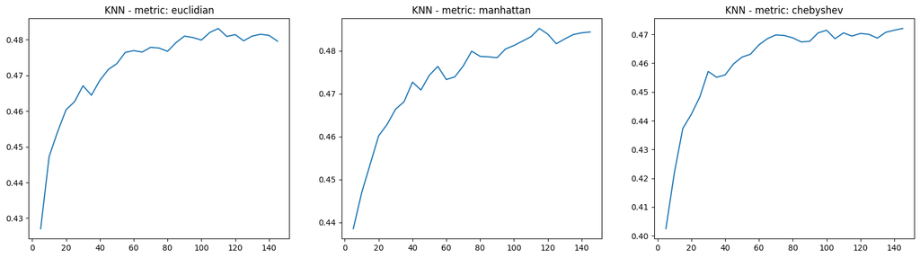

```python
euclidian = gs_knn.cv_results_['mean_test_score'][:len(n_neighbors)]
manhattan = gs_knn.cv_results_['mean_test_score'][len(n_neighbors):2*len(n_neighbors)]
chebyshev = gs_knn.cv_results_['mean_test_score'][2*len(n_neighbors):]
fig, (ax1, ax2, ax3) = plt.subplots(1, 3, figsize=(20, 5))
ax1.plot(n_neighbors, euclidian)
ax1.set_title('KNN - metric: euclidian')
ax2.plot(n_neighbors, manhattan)
ax2.set_title('KNN - metric: manhattan')
ax3.plot(n_neighbors, chebyshev)
ax3.set_title('KNN - metric: chebyshev')
```

Nous pouvons remarquer avec les figures ci-dessus l'évolution du score par rapport au nombre de voisins pour chaque métrique utilisé. Nous observons l'effet du overfitting quand nous avons un nombre des voisins faibles. C'est possible de remarquer aussi une stabilisation de l'évolution du score après 100 voisins.

```
<sklearn.metrics._plot.confusion_matrix.ConfusionMatrixDisplay at 0x1d441327940>
```

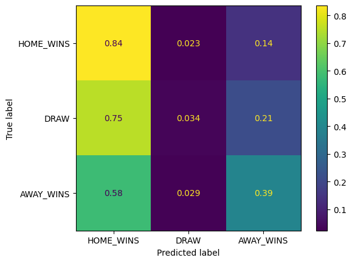

```python
y_pred = gs_knn.predict(X_test_scaled)
cm = confusion_matrix(y_test, y_pred, normalize='true')
ConfusionMatrixDisplay(cm, display_labels=['HOME_WINS', 'DRAW', 'AWAY_WINS']).plot()
```

## Regression Logistique

```python
log_reg = LogisticRegression(max_iter=10000, random_state=42)
log_reg.fit(X_train_scaled, y_train)
```

```
LogisticRegression(max_iter=10000, random_state=42)
```

```python
y_pred = log_reg.predict(X_test_scaled)
score_reglog = accuracy_score(y_test, y_pred)
score_reglog
```

```
0.4839496139780577
```

```
<sklearn.metrics._plot.confusion_matrix.ConfusionMatrixDisplay at 0x1d4417a2f40>
```

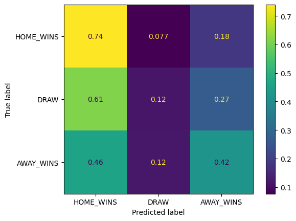

```python
cm_logreg = confusion_matrix(y_test, y_pred, normalize='true')
ConfusionMatrixDisplay(cm_logreg, display_labels=['HOME_WINS', 'DRAW', 'AWAY_WINS']).plot()
```

```python
param_grid = {
    'C': [0.001, 0.01, 0.1, 1, 10],
    'solver': ['liblinear', 'saga'],
    'penalty': ['l2']
}
```

```python
gs_log_reg = GridSearchCV(estimator=log_reg, param_grid=param_grid, cv=5, scoring='accuracy', n_jobs=-1)
gs_log_reg.fit(X_train_scaled, y_train)
```

```
GridSearchCV(cv=5,
             estimator=LogisticRegression(max_iter=10000, random_state=42),
             n_jobs=-1,
             param_grid={'C': [0.001, 0.01, 0.1, 1, 10], 'penalty': ['l2'],
                         'solver': ['liblinear', 'saga']},
             scoring='accuracy')
```

```python
best_params = gs_log_reg.best_params_
print(f"Best parameters: {best_params}")
best_log_reg = gs_log_reg.best_estimator_
print(f"Best estimator: {best_log_reg}")
```

```
Best parameters: {'C': 0.001, 'penalty': 'l2', 'solver': 'saga'}
Best estimator: LogisticRegression(C=0.001, max_iter=10000, random_state=42, solver='saga')
```

```python
y_pred = gs_log_reg.predict(X_test_scaled)
score_reglog_hyp = accuracy_score(y_test, y_pred)
score_reglog_hyp
```

```
0.49573344169036976
```

```
<sklearn.metrics._plot.confusion_matrix.ConfusionMatrixDisplay at 0x1d441102310>
```

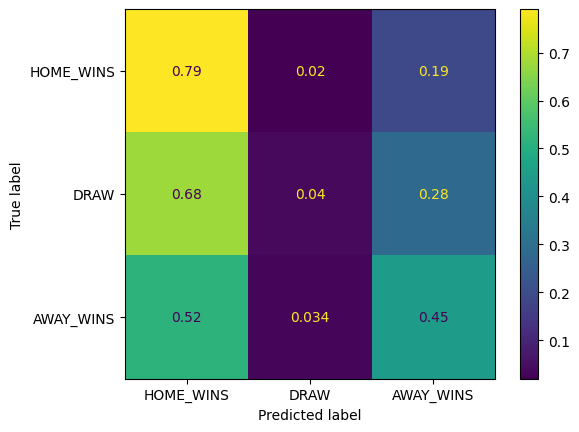

```python
cm_gs_logreg = confusion_matrix(y_test, y_pred, normalize='true')
ConfusionMatrixDisplay(cm_gs_logreg, display_labels=['HOME_WINS', 'DRAW', 'AWAY_WINS']).plot()
```

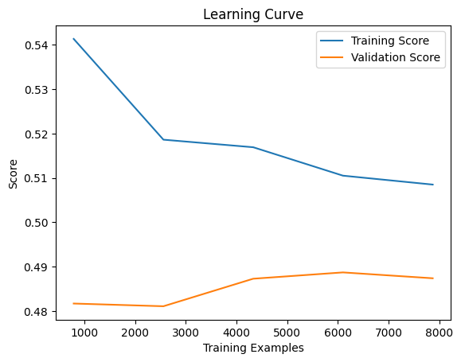

```python
train_sizes, train_scores, test_scores = learning_curve(
    best_log_reg, X_train_scaled, y_train, cv=5
)

train_scores_mean = train_scores.mean(axis=1)
test_scores_mean = test_scores.mean(axis=1)

plt.plot(train_sizes, train_scores_mean, label='Training Score')
plt.plot(train_sizes, test_scores_mean, label='Validation Score')
plt.xlabel('Training Examples')
plt.ylabel('Score')
plt.legend()
plt.title('Learning Curve')
plt.show()
```

## Neural Network

```python
# Standardize features
scaler = StandardScaler()
X_train_scaled = scaler.fit_transform(X_train)
X_val_scaled = scaler.transform(X_test)

# Define the model
nn_model = tf.keras.Sequential([
    tf.keras.layers.Dense(64, activation='relu', input_shape=(X_train.shape[1],)),
    tf.keras.layers.Dropout(0.3),  # Regularization
    tf.keras.layers.Dense(32, activation='relu'),
    tf.keras.layers.Dense(len(y_train.unique()), activation='softmax')  # Multiclass classification
])

# Compile the model
nn_model.compile(optimizer='adam', loss='sparse_categorical_crossentropy', metrics=['accuracy'])

# Train the model
nn_model.fit(X_train_scaled, y_train, epochs=50, batch_size=32, validation_data=(X_val_scaled, y_test), verbose=1)

# Predict and evaluate
y_pred_nn = nn_model.predict(X_val_scaled)
y_pred_nn_classes = y_pred_nn.argmax(axis=1)
nn_accuracy = accuracy_score(y_test, y_pred_nn_classes)
print("Neural Network Accuracy:", nn_accuracy)
```

```
308/308 ━━━━━━━━━━━━━━━━━━━━ 3s 5ms/step - accuracy: 0.4140 - loss: 1.1537 - val_accuracy: 0.4762 - val_loss: 1.0380
308/308 ━━━━━━━━━━━━━━━━━━━━ 1s 3ms/step - accuracy: 0.4738 - loss: 1.0349 - val_accuracy: 0.4783 - val_loss: 1.0357
308/308 ━━━━━━━━━━━━━━━━━━━━ 1s 3ms/step - accuracy: 0.5027 - loss: 1.0057 - val_accuracy: 0.4819 - val_loss: 1.0350
308/308 ━━━━━━━━━━━━━━━━━━━━ 1s 4ms/step - accuracy: 0.5108 - loss: 0.9984 - val_accuracy: 0.4783 - val_loss: 1.0331
308/308 ━━━━━━━━━━━━━━━━━━━━ 1s 3ms/step - accuracy: 0.5126 - loss: 0.9909 - val_accuracy: 0.4860 - val_loss: 1.0340
308/308 ━━━━━━━━━━━━━━━━━━━━ 1s 4ms/step - accuracy: 0.5296 - loss: 0.9688 - val_accuracy: 0.4787 - val_loss: 1.0449
308/308 ━━━━━━━━━━━━━━━━━━━━ 1s 4ms/step - accuracy: 0.5336 - loss: 0.9645 - val_accuracy: 0.4673 - val_loss: 1.0534
308/308 ━━━━━━━━━━━━━━━━━━━━ 1s 3ms/step - accuracy: 0.5443 - loss: 0.9595 - val_accuracy: 0.4811 - val_loss: 1.0508
308/308 ━━━━━━━━━━━━━━━━━━━━ 1s 3ms/step - accuracy: 0.5489 - loss: 0.9436 - val_accuracy: 0.4762 - val_loss: 1.0540
308/308 ━━━━━━━━━━━━━━━━━━━━ 1s 3ms/step - accuracy: 0.5499 - loss: 0.9441 - val_accuracy: 0.4726 - val_loss: 1.0572
308/308 ━━━━━━━━━━━━━━━━━━━━ 1s 3ms/step - accuracy: 0.5653 - loss: 0.9272 - val_accuracy: 0.4730 - val_loss: 1.0656
308/308 ━━━━━━━━━━━━━━━━━━━━ 1s 3ms/step - accuracy: 0.5609 - loss: 0.9229 - val_accuracy: 0.4758 - val_loss: 1.0645
308/308 ━━━━━━━━━━━━━━━━━━━━ 1s 4ms/step - accuracy: 0.5769 - loss: 0.9007 - val_accuracy: 0.4714 - val_loss: 1.0727
308/308 ━━━━━━━━━━━━━━━━━━━━ 1s 3ms/step - accuracy: 0.5744 - loss: 0.9100 - val_accuracy: 0.4783 - val_loss: 1.0736
308/308 ━━━━━━━━━━━━━━━━━━━━ 1s 3ms/step - accuracy: 0.5738 - loss: 0.9089 - val_accuracy: 0.4714 - val_loss: 1.0845
308/308 ━━━━━━━━━━━━━━━━━━━━ 1s 3ms/step - accuracy: 0.5858 - loss: 0.8917 - val_accuracy: 0.4714 - val_loss: 1.0822
308/308 ━━━━━━━━━━━━━━━━━━━━ 1s 3ms/step - accuracy: 0.5914 - loss: 0.8755 - val_accuracy: 0.4620 - val_loss: 1.0857
308/308 ━━━━━━━━━━━━━━━━━━━━ 1s 3ms/step - accuracy: 0.6010 - loss: 0.8735 - val_accuracy: 0.4657 - val_loss: 1.1058
308/308 ━━━━━━━━━━━━━━━━━━━━ 1s 3ms/step - accuracy: 0.5907 - loss: 0.8849 - val_accuracy: 0.4649 - val_loss: 1.1083
308/308 ━━━━━━━━━━━━━━━━━━━━ 1s 3ms/step - accuracy: 0.6052 - loss: 0.8601 - val_accuracy: 0.4612 - val_loss: 1.1095
308/308 ━━━━━━━━━━━━━━━━━━━━ 1s 3ms/step - accuracy: 0.6069 - loss: 0.8542 - val_accuracy: 0.4636 - val_loss: 1.1120
308/308 ━━━━━━━━━━━━━━━━━━━━ 1s 3ms/step - accuracy: 0.6113 - loss: 0.8556 - val_accuracy: 0.4620 - val_loss: 1.1191
308/308 ━━━━━━━━━━━━━━━━━━━━ 1s 3ms/step - accuracy: 0.6236 - loss: 0.8307 - val_accuracy: 0.4612 - val_loss: 1.1303
308/308 ━━━━━━━━━━━━━━━━━━━━ 1s 3ms/step - accuracy: 0.6191 - loss: 0.8321 - val_accuracy: 0.4458 - val_loss: 1.1239
308/308 ━━━━━━━━━━━━━━━━━━━━ 1s 3ms/step - accuracy: 0.6271 - loss: 0.8204 - val_accuracy: 0.4478 - val_loss: 1.1315
308/308 ━━━━━━━━━━━━━━━━━━━━ 1s 3ms/step - accuracy: 0.6298 - loss: 0.8120 - val_accuracy: 0.4608 - val_loss: 1.1377
308/308 ━━━━━━━━━━━━━━━━━━━━ 1s 3ms/step - accuracy: 0.6434 - loss: 0.7997 - val_accuracy: 0.4514 - val_loss: 1.1425
308/308 ━━━━━━━━━━━━━━━━━━━━ 1s 3ms/step - accuracy: 0.6457 - loss: 0.8009 - val_accuracy: 0.4453 - val_loss: 1.1541
308/308 ━━━━━━━━━━━━━━━━━━━━ 1s 3ms/step - accuracy: 0.6402 - loss: 0.7920 - val_accuracy: 0.4523 - val_loss: 1.1605
308/308 ━━━━━━━━━━━━━━━━━━━━ 2s 3ms/step - accuracy: 0.6521 - loss: 0.7876 - val_accuracy: 0.4445 - val_loss: 1.1698
308/308 ━━━━━━━━━━━━━━━━━━━━ 1s 3ms/step - accuracy: 0.6479 - loss: 0.7826 - val_accuracy: 0.4510 - val_loss: 1.1720
308/308 ━━━━━━━━━━━━━━━━━━━━ 1s 3ms/step - accuracy: 0.6512 - loss: 0.7864 - val_accuracy: 0.4482 - val_loss: 1.1852
308/308 ━━━━━━━━━━━━━━━━━━━━ 1s 3ms/step - accuracy: 0.6578 - loss: 0.7741 - val_accuracy: 0.4384 - val_loss: 1.1677
308/308 ━━━━━━━━━━━━━━━━━━━━ 1s 3ms/step - accuracy: 0.6610 - loss: 0.7757 - val_accuracy: 0.4421 - val_loss: 1.1845
308/308 ━━━━━━━━━━━━━━━━━━━━ 1s 3ms/step - accuracy: 0.6632 - loss: 0.7652 - val_accuracy: 0.4429 - val_loss: 1.1909
308/308 ━━━━━━━━━━━━━━━━━━━━ 1s 3ms/step - accuracy: 0.6668 - loss: 0.7611 - val_accuracy: 0.4372 - val_loss: 1.1986
308/308 ━━━━━━━━━━━━━━━━━━━━ 1s 3ms/step - accuracy: 0.6673 - loss: 0.7602 - val_accuracy: 0.4474 - val_loss: 1.1967
308/308 ━━━━━━━━━━━━━━━━━━━━ 1s 3ms/step - accuracy: 0.6616 - loss: 0.7525 - val_accuracy: 0.4291 - val_loss: 1.2097
308/308 ━━━━━━━━━━━━━━━━━━━━ 1s 3ms/step - accuracy: 0.6693 - loss: 0.7553 - val_accuracy: 0.4449 - val_loss: 1.2152
308/308 ━━━━━━━━━━━━━━━━━━━━ 1s 3ms/step - accuracy: 0.6734 - loss: 0.7391 - val_accuracy: 0.4458 - val_loss: 1.2159
308/308 ━━━━━━━━━━━━━━━━━━━━ 1s 3ms/step - accuracy: 0.6687 - loss: 0.7488 - val_accuracy: 0.4417 - val_loss: 1.2213
308/308 ━━━━━━━━━━━━━━━━━━━━ 1s 3ms/step - accuracy: 0.6722 - loss: 0.7326 - val_accuracy: 0.4486 - val_loss: 1.2496
308/308 ━━━━━━━━━━━━━━━━━━━━ 1s 3ms/step - accuracy: 0.6759 - loss: 0.7386 - val_accuracy: 0.4470 - val_loss: 1.2391
308/308 ━━━━━━━━━━━━━━━━━━━━ 1s 3ms/step - accuracy: 0.6711 - loss: 0.7420 - val_accuracy: 0.4518 - val_loss: 1.2479
308/308 ━━━━━━━━━━━━━━━━━━━━ 1s 3ms/step - accuracy: 0.6862 - loss: 0.7271 - val_accuracy: 0.4514 - val_loss: 1.2404
308/308 ━━━━━━━━━━━━━━━━━━━━ 1s 3ms/step - accuracy: 0.6921 - loss: 0.7182 - val_accuracy: 0.4169 - val_loss: 1.2412
308/308 ━━━━━━━━━━━━━━━━━━━━ 1s 3ms/step - accuracy: 0.6843 - loss: 0.7161 - val_accuracy: 0.4425 - val_loss: 1.2650
308/308 ━━━━━━━━━━━━━━━━━━━━ 1s 3ms/step - accuracy: 0.6905 - loss: 0.7092 - val_accuracy: 0.4518 - val_loss: 1.2664
308/308 ━━━━━━━━━━━━━━━━━━━━ 1s 3ms/step - accuracy: 0.6849 - loss: 0.7072 - val_accuracy: 0.4380 - val_loss: 1.2647
308/308 ━━━━━━━━━━━━━━━━━━━━ 1s 3ms/step - accuracy: 0.6894 - loss: 0.7026 - val_accuracy: 0.4380 - val_loss: 1.2559
77/77 ━━━━━━━━━━━━━━━━━━━━ 0s 3ms/step
Neural Network Accuracy: 0.4380333197887038
```

```python
y_pred_nn_classes
```

```
array([0, 2, 1, ..., 1, 1, 2], dtype=int64)
```

```python
# Standardize features
scaler = StandardScaler()
X_train_scaled = scaler.fit_transform(X_train)
X_val_scaled = scaler.transform(X_test)

# Define the model
nn_model = tf.keras.Sequential([
    tf.keras.layers.Dense(128, activation='relu', input_shape=(X_train.shape[1],)),
    tf.keras.layers.BatchNormalization(),
    tf.keras.layers.Dropout(0.4),
    tf.keras.layers.Dense(64, activation='relu'),
    tf.keras.layers.BatchNormalization(),
    tf.keras.layers.Dropout(0.3),
    tf.keras.layers.Dense(32, activation='relu'),
    tf.keras.layers.Dense(len(y_train.unique()), activation='softmax')  # Multiclass classification
])

# Compile the model
nn_model.compile(
    optimizer=tf.keras.optimizers.Adam(learning_rate=0.001),
    loss='sparse_categorical_crossentropy',
    metrics=['accuracy']
)

# Early stopping and learning rate scheduler
early_stopping = EarlyStopping(monitor='val_loss', patience=10, restore_best_weights=True)
reduce_lr = ReduceLROnPlateau(monitor='val_loss', factor=0.5, patience=5, min_lr=1e-5)

# Train the model
history = nn_model.fit(
    X_train_scaled, y_train,
    epochs=100,
    batch_size=64,
    validation_data=(X_val_scaled, y_test),
    callbacks=[early_stopping, reduce_lr],
    verbose=1
)

# Predict and evaluate
y_pred_nn = nn_model.predict(X_val_scaled)
y_pred_nn_classes = y_pred_nn.argmax(axis=1)
nn_accuracy_standardised = accuracy_score(y_test, y_pred_nn_classes)
print("Neural Network Accuracy:", nn_accuracy)
```

```
154/154 ━━━━━━━━━━━━━━━━━━━━ 4s 7ms/step - accuracy: 0.3813 - loss: 1.2439 - val_accuracy: 0.4673 - val_loss: 1.0428 - learning_rate: 0.0010
154/154 ━━━━━━━━━━━━━━━━━━━━ 1s 4ms/step - accuracy: 0.4747 - loss: 1.0593 - val_accuracy: 0.4709 - val_loss: 1.0357 - learning_rate: 0.0010
154/154 ━━━━━━━━━━━━━━━━━━━━ 1s 4ms/step - accuracy: 0.4643 - loss: 1.0476 - val_accuracy: 0.4632 - val_loss: 1.0346 - learning_rate: 0.0010
154/154 ━━━━━━━━━━━━━━━━━━━━ 1s 5ms/step - accuracy: 0.4726 - loss: 1.0394 - val_accuracy: 0.4799 - val_loss: 1.0283 - learning_rate: 0.0010
154/154 ━━━━━━━━━━━━━━━━━━━━ 1s 4ms/step - accuracy: 0.4937 - loss: 1.0149 - val_accuracy: 0.4795 - val_loss: 1.0300 - learning_rate: 0.0010
154/154 ━━━━━━━━━━━━━━━━━━━━ 1s 4ms/step - accuracy: 0.4969 - loss: 1.0060 - val_accuracy: 0.4811 - val_loss: 1.0296 - learning_rate: 0.0010
154/154 ━━━━━━━━━━━━━━━━━━━━ 1s 4ms/step - accuracy: 0.4982 - loss: 1.0074 - val_accuracy: 0.4856 - val_loss: 1.0291 - learning_rate: 0.0010
154/154 ━━━━━━━━━━━━━━━━━━━━ 1s 5ms/step - accuracy: 0.4955 - loss: 1.0103 - val_accuracy: 0.4803 - val_loss: 1.0309 - learning_rate: 0.0010
154/154 ━━━━━━━━━━━━━━━━━━━━ 1s 5ms/step - accuracy: 0.5092 - loss: 1.0079 - val_accuracy: 0.4872 - val_loss: 1.0317 - learning_rate: 0.0010
154/154 ━━━━━━━━━━━━━━━━━━━━ 1s 4ms/step - accuracy: 0.5034 - loss: 0.9965 - val_accuracy: 0.4896 - val_loss: 1.0311 - learning_rate: 5.0000e-04
154/154 ━━━━━━━━━━━━━━━━━━━━ 1s 4ms/step - accuracy: 0.5059 - loss: 0.9882 - val_accuracy: 0.4799 - val_loss: 1.0336 - learning_rate: 5.0000e-04
154/154 ━━━━━━━━━━━━━━━━━━━━ 1s 4ms/step - accuracy: 0.5131 - loss: 0.9846 - val_accuracy: 0.4811 - val_loss: 1.0361 - learning_rate: 5.0000e-04
154/154 ━━━━━━━━━━━━━━━━━━━━ 1s 5ms/step - accuracy: 0.5104 - loss: 0.9862 - val_accuracy: 0.4758 - val_loss: 1.0399 - learning_rate: 5.0000e-04
154/154 ━━━━━━━━━━━━━━━━━━━━ 1s 4ms/step - accuracy: 0.5260 - loss: 0.9721 - val_accuracy: 0.4844 - val_loss: 1.0395 - learning_rate: 5.0000e-04
77/77 ━━━━━━━━━━━━━━━━━━━━ 1s 5ms/step
Neural Network Accuracy: 0.4380333197887038
```

```python
y_pred_nn
```

```
array([[0.6590338 , 0.24976698, 0.09119915],
       [0.39969328, 0.27815464, 0.32215208],
       [0.32808694, 0.28100342, 0.39090958],
       ...,
       [0.19851972, 0.34597915, 0.45550117],
       [0.44448298, 0.23775527, 0.31776172],
       [0.27750102, 0.26731077, 0.45518816]], dtype=float32)
```

The neural network model outputs probabilities (which are floating-point numbers) for each class (0, 1, or 2) rather than directly predicting one of those classes. However, since y_test contains integer labels (0, 1, 2), we need to convert the floating-point predictions into class labels using argmax(axis=1) to convert the predicted probabilities into the class with the highest probability

```python
y_pred_nn_classes
```

```
array([0, 0, 2, ..., 2, 0, 0], dtype=int64)
```

## xgb model

```python
xgb = XGBClassifier(
    objective='multi:softmax',
    num_class=3,
    eta=0.1,
    n_estimators=100,
    n_jobs=-1
)

param_grid_xgb = {
    'max_depth': [3, 6, 12],
    'reg_lambda': [0, 0.1, 0.5, 1, 2, 5],
    'reg_alpha': [0, 0.1, 0.5, 1, 2, 5]
}

gs_xgb = GridSearchCV(xgb, param_grid=param_grid_xgb, cv=5, n_jobs=-1, verbose=10).fit(X_train_imp, y_train)
```

```
Fitting 5 folds for each of 108 candidates, totalling 540 fits
```

```python
best_params_xgb_tmp = gs_xgb.best_params_
score_xgb_tmp = gs_xgb.score(imputer.transform(X_test), y_test)

print(f'{best_params_xgb_tmp=}')
print(f'{score_xgb_tmp=}')
```

```
best_params_xgb_tmp={'max_depth': 3, 'reg_alpha': 0.1, 'reg_lambda': 0.1}
score_xgb_tmp=0.4973587972368956
```

```python
xgb = XGBClassifier(
    objective='multi:softmax',
    num_class=3,
    n_estimators=100,
    n_jobs=-1,
    max_depth=best_params_xgb_tmp['max_depth'],
    reg_alpha=best_params_xgb_tmp['reg_alpha'],
    reg_lambda=best_params_xgb_tmp['reg_lambda'],
)

param_grid_xgb2 = {
    'eta': [0.01, 0.05, 0.02, 0.03, 0.04, 0.05, 0.06, 0.07, 0.08, 0.09, 0.1, 0.15, 0.22, 0.25, 0.3, 0.4, 0.5, 0.6, 0.7, 0.8, 0.9, 1]
}

gs_xgb_final = GridSearchCV(xgb, param_grid=param_grid_xgb2, cv=5, n_jobs=-1, verbose=10).fit(X_train_imp, y_train)
```

```
Fitting 5 folds for each of 22 candidates, totalling 110 fits
```

```python
best_params_xgb = gs_xgb_final.best_params_
score_xgb = gs_xgb_final.score(imputer.transform(X_test), y_test)

print(f'{best_params_xgb=}')
print(f'{score_xgb=}')
```

```
best_params_xgb={'eta': 0.06}
score_xgb=0.4912637139374238
```

Nous allons analyser l'importance des variables sur cette modèle

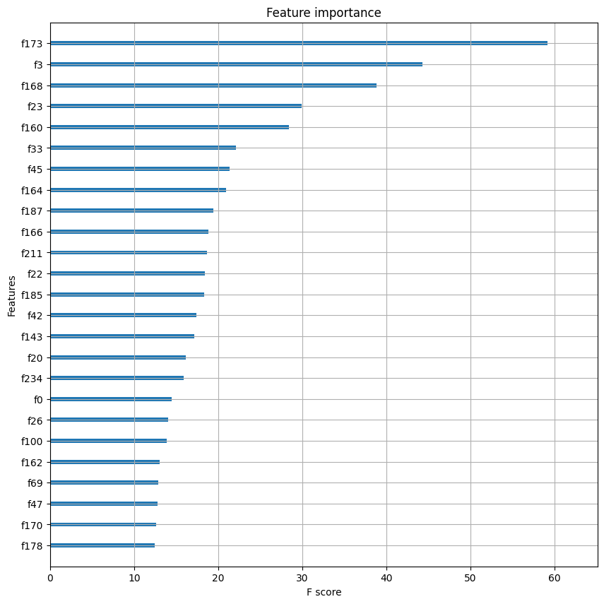

```python
plot_importance(gs_xgb_final.best_estimator_, max_num_features=25, importance_type='gain', show_values=False)
fig = plt.gcf()
fig.set_size_inches(10, 10)
```

```python
feat_import_idx = np.argsort(gs_xgb_final.best_estimator_.feature_importances_)[::-1]
sorted_feat_import = gs_xgb_final.best_estimator_.feature_importances_[feat_import_idx]

# retrieving features that have more than 1% of importance
most_import = sorted_feat_import[sorted_feat_import > 0.01]
cols_to_keep = X_train.columns[feat_import_idx[:len(most_import)]]

print(f"Nombre de colonnes avec plus de 1% d'importance: {len(cols_to_keep)}")
```

```
Nombre de colonnes avec plus de 1% d'importance: 13
```

Nous allons entraîner un nouvelle modèle en n'utilisant que les variables avec > 1% d'importance

```python
xgb = XGBClassifier(
    objective='multi:softmax',
    num_class=3,
    n_estimators=100,
    n_jobs=-1,
    max_depth=best_params_xgb_tmp['max_depth'],
    reg_alpha=best_params_xgb_tmp['reg_alpha'],
    reg_lambda=best_params_xgb_tmp['reg_lambda'],
    eta=best_params_xgb['eta']
)

xgb = xgb.fit(
    pd.DataFrame(X_train_imp, columns=X_train.columns)[cols_to_keep],
    y_train)
```

```python
score_xgb_var_imp =  xgb.score(
    pd.DataFrame(imputer.transform(X_test), columns=X_test.columns)[cols_to_keep],
    y_test)
print(f'{score_xgb_var_imp=}')
```

```
score_xgb_var_imp=0.4965461194636327
```

Automated Tuning: Use Optuna:

```python
def objective(trial):
    params = {
        'objective': 'multi:softmax',
        'num_class': 3,
        'max_depth': trial.suggest_int('max_depth', 4, 12),
        'learning_rate': trial.suggest_loguniform('learning_rate', 0.01, 0.3),
        'subsample': trial.suggest_uniform('subsample', 0.6, 1.0),
        'colsample_bytree': trial.suggest_uniform('colsample_bytree', 0.6, 1.0),
        'alpha': trial.suggest_loguniform('alpha', 0.01, 10),
        'lambda': trial.suggest_loguniform('lambda', 0.01, 10),
        'eval_metric': 'mlogloss',
        'random_state': 42
    }
    dtrain = xgb.DMatrix(X_train_scaled, label=y_train)
    dval = xgb.DMatrix(X_test, label=y_test)
    evals = [(dtrain, 'train'), (dval, 'eval')]
    model = xgb.train(params, dtrain, evals=evals, early_stopping_rounds=50, verbose_eval=False)
    y_pred = model.predict(dval)
    return accuracy_score(y_test, y_pred)

study = optuna.create_study(direction='maximize')
study.optimize(objective, n_trials=50)
print("Best Parameters:", study.best_params)
```

```
[I 2024-12-05 23:50:18,070] A new study created in memory with name: no-name-3623f02c-b509-4aa6-bbb7-834b80b9436d
[I 2024-12-05 23:50:18,438] Trial 0 finished with value: 0.49573344169036976 and parameters: {'max_depth': 5, 'learning_rate': 0.027901509724246897, 'subsample': 0.848918699075871, 'colsample_bytree': 0.8512444966522132, 'alpha': 7.055816598406043, 'lambda': 0.017377290513743288}. Best is trial 0 wi…
[I 2024-12-05 23:50:19,351] Trial 1 finished with value: 0.4721657862657456 and parameters: {'max_depth': 11, 'learning_rate': 0.0371552334913955, 'subsample': 0.9201582137926705, 'colsample_bytree': 0.828153415871962, 'alpha': 0.605019302816249, 'lambda': 0.0857451251566356}. Best is trial 0 with v…
[I 2024-12-05 23:50:19,734] Trial 2 finished with value: 0.4855749695245835 and parameters: {'max_depth': 6, 'learning_rate': 0.05209139147933494, 'subsample': 0.7106222725003328, 'colsample_bytree': 0.8496075005722402, 'alpha': 0.22748641881675735, 'lambda': 4.9552102688636435}. Best is trial 0 wit…
[I 2024-12-05 23:50:21,187] Trial 3 finished with value: 0.47947988622511173 and parameters: {'max_depth': 12, 'learning_rate': 0.02962562828525379, 'subsample': 0.9873235903394721, 'colsample_bytree': 0.6898273826459951, 'alpha': 0.051549753642900036, 'lambda': 3.4282274732413147}. Best is trial 0 …
[I 2024-12-05 23:50:21,580] Trial 4 finished with value: 0.4949207639171069 and parameters: {'max_depth': 4, 'learning_rate': 0.013257537511538152, 'subsample': 0.6636532125946225, 'colsample_bytree': 0.9228208392797179, 'alpha': 0.04330757003408379, 'lambda': 5.283798668436854}. Best is trial 0 wit…
[I 2024-12-05 23:50:22,062] Trial 5 finished with value: 0.4937017472572125 and parameters: {'max_depth': 6, 'learning_rate': 0.042298010651096174, 'subsample': 0.8297628709263402, 'colsample_bytree': 0.6052373787828061, 'alpha': 0.4469206997461777, 'lambda': 0.010518992223030273}. Best is trial 0 w…
[I 2024-12-05 23:50:22,919] Trial 6 finished with value: 0.4656643640796424 and parameters: {'max_depth': 10, 'learning_rate': 0.04358095081915832, 'subsample': 0.791225865010827, 'colsample_bytree': 0.906126356588669, 'alpha': 1.1984422180049292, 'lambda': 0.06427223331847837}. Best is trial 0 with…
[I 2024-12-05 23:50:23,556] Trial 7 finished with value: 0.48191791954490043 and parameters: {'max_depth': 9, 'learning_rate': 0.0757260957651905, 'subsample': 0.9980103204887456, 'colsample_bytree': 0.7575977107778626, 'alpha': 2.5752637240719447, 'lambda': 6.751673322652826}. Best is trial 0 with …
[I 2024-12-05 23:50:24,742] Trial 8 finished with value: 0.452661519707436 and parameters: {'max_depth': 12, 'learning_rate': 0.2270915561598595, 'subsample': 0.8246687152855545, 'colsample_bytree': 0.9181677355655038, 'alpha': 1.1473782861274275, 'lambda': 0.02873715005704525}. Best is trial 0 with…
[I 2024-12-05 23:50:26,206] Trial 9 finished with value: 0.4782608695652174 and parameters: {'max_depth': 11, 'learning_rate': 0.03971248586573748, 'subsample': 0.9263400196870224, 'colsample_bytree': 0.7238670231991206, 'alpha': 0.01463398757014152, 'lambda': 5.757725415313634}. Best is trial 0 wit…
[I 2024-12-05 23:50:26,586] Trial 10 finished with value: 0.49085737505079235 and parameters: {'max_depth': 4, 'learning_rate': 0.010856759415822157, 'subsample': 0.7494663613209702, 'colsample_bytree': 0.9659923611499385, 'alpha': 7.658525156098712, 'lambda': 0.5259963649381181}. Best is trial 0 wi…
[I 2024-12-05 23:50:26,922] Trial 11 finished with value: 0.48923201950426654 and parameters: {'max_depth': 4, 'learning_rate': 0.01247855415024462, 'subsample': 0.6148595079660145, 'colsample_bytree': 0.9966570847683929, 'alpha': 0.0937039443140222, 'lambda': 0.8071302101995146}. Best is trial 0 wi…
[I 2024-12-05 23:50:27,295] Trial 12 finished with value: 0.4904510361641609 and parameters: {'max_depth': 6, 'learning_rate': 0.02132128635877524, 'subsample': 0.615347577683716, 'colsample_bytree': 0.8779855978266341, 'alpha': 0.011926423423794122, 'lambda': 1.5262588715171337}. Best is trial 0 wi…
```

[output cut: 37 more lines]

```
Best Parameters: {'max_depth': 6, 'learning_rate': 0.03285413747125799, 'subsample': 0.7470045598057964, 'colsample_bytree': 0.7880567474546822, 'alpha': 4.417382778396881, 'lambda': 3.495637920278947}
```

```python
#using best params
# XGBoost parameters
best_params = {
    'objective': 'multi:softmax',  # for classification
    'num_class': 3,  # number of classes
    'max_depth': 6,
    'learning_rate': 0.03285413747125799,
    'n_estimators': 1000,
    'subsample': 0.7470045598057964,
    'colsample_bytree': 0.7880567474546822,
    'alpha': 4.417382778396881,  # L1 regularization
    'lambda': 3.495637920278947,  # L2 regularization
    'eval_metric': 'mlogloss',
    'random_state': 42
}

# Convert to DMatrix
dtrain = xgb.DMatrix(X_train_scaled, label=y_train)
dval = xgb.DMatrix(X_test, label=y_test)

# Train with early stopping
evals = [(dtrain, 'train'), (dval, 'eval')]
xgb_model = xgb.train(
    best_params, dtrain, num_boost_round=10000, evals=evals,
    early_stopping_rounds=100, verbose_eval=100
)

# Predictions
y_pred = xgb_model.predict(xgb.DMatrix(X_test))
xgb_optuna_accuracy = accuracy_score(y_test, y_pred)
print("Validation Accuracy:", xgb_optuna_accuracy)
```

```
Validation Accuracy: 0.4953271028037383
```

## Catboost model

```python
params = {
    'iterations': [500, 1000],
    'learning_rate': [0.01, 0.03, 0.05],
    'depth': [6, 8, 10],
    'l2_leaf_reg': [3, 5, 7],
    'bagging_temperature': [0.2, 0.5, 1.0]
}

catboost = CatBoostClassifier(loss_function='MultiClass', random_seed=42, verbose=0)
grid = GridSearchCV(catboost, param_grid=params, scoring='accuracy', cv=3)
grid.fit(X_train_scaled, y_train)

print("Best Parameters:", grid.best_params_)
catboost_model = grid.best_estimator_
```

```
Best Parameters: {'bagging_temperature': 0.2, 'depth': 6, 'iterations': 1000, 'l2_leaf_reg': 7, 'learning_rate': 0.01}
```

```python
# Initialize CatBoost with tuned hyperparameters
cat_model = CatBoostClassifier(
    iterations=1000,
    depth=10,
    learning_rate=0.03,
    loss_function='MultiClass',
    eval_metric='Accuracy',
    random_seed=42,
    class_weights=class_weights_dict,
    early_stopping_rounds=50
)

# Stratified K-Fold for robust evaluation
kf = StratifiedKFold(n_splits=5, shuffle=True, random_state=42)
accuracies = []

for train_idx, val_idx in kf.split(X_train_scaled, y_train):
    X_train_fold, X_val_fold = X_train_scaled.iloc[train_idx], X_train_scaled.iloc[val_idx]
    y_train_fold, y_val_fold = y_train.iloc[train_idx], y_train.iloc[val_idx]

    cat_model.fit(
        X_train_fold, y_train_fold,
        eval_set=(X_val_fold, y_val_fold),
        verbose=100,
        plot=False
    )
    y_pred_val = cat_model.predict(X_val_fold)
    accuracy = accuracy_score(y_val_fold, y_pred_val)
    accuracies.append(accuracy)

# Average accuracy across folds
print(f"Cross-validated Accuracy: {sum(accuracies) / len(accuracies)}")

# Final fit on full training data
cat_model.fit(X_train_scaled, y_train, eval_set=(X_test, y_test), verbose=100, plot=True)

# Predict and evaluate
y_pred = cat_model.predict(X_test)
final_accuracy = accuracy_score(y_test, y_pred)
print("Final Accuracy:", final_accuracy)
```

```
0:	learn: 0.5150830	test: 0.3887618	best: 0.3887618 (0)	total: 108ms	remaining: 1m 47s
100:	learn: 0.8226372	test: 0.4468185	best: 0.4611334 (54)	total: 9.59s	remaining: 1m 25s
Stopped by overfitting detector  (50 iterations wait)

bestTest = 0.4611334192
bestIteration = 54

Shrink model to first 55 iterations.
0:	learn: 0.5080658	test: 0.3718923	best: 0.3718923 (0)	total: 84.6ms	remaining: 1m 24s
100:	learn: 0.8184713	test: 0.4480716	best: 0.4581076 (55)	total: 11.1s	remaining: 1m 39s
Stopped by overfitting detector  (50 iterations wait)

bestTest = 0.4581075732
bestIteration = 55

Shrink model to first 56 iterations.
0:	learn: 0.5319136	test: 0.3790888	best: 0.3790888 (0)	total: 132ms	remaining: 2m 12s
100:	learn: 0.8104818	test: 0.4316825	best: 0.4376262 (81)	total: 12.9s	remaining: 1m 55s
Stopped by overfitting detector  (50 iterations wait)

bestTest = 0.4376261806
bestIteration = 81

Shrink model to first 82 iterations.
0:	learn: 0.5074598	test: 0.3988399	best: 0.3988399 (0)	total: 105ms	remaining: 1m 45s
100:	learn: 0.8228550	test: 0.4371360	best: 0.4448692 (70)	total: 11.6s	remaining: 1m 43s
Stopped by overfitting detector  (50 iterations wait)

bestTest = 0.4448691658
bestIteration = 70

Shrink model to first 71 iterations.
0:	learn: 0.5141024	test: 0.3993225	best: 0.3993225 (0)	total: 119ms	remaining: 1m 58s
Stopped by overfitting detector  (50 iterations wait)

bestTest = 0.4310819369
bestIteration = 30

Shrink model to first 31 iterations.
Cross-validated Accuracy: 0.4626067873172383
```

```
MetricVisualizer(layout=Layout(align_self='stretch', height='500px'))
```

```
0:	learn: 0.4856109	test: 0.3978106	best: 0.3978106 (0)	total: 360ms	remaining: 5m 59s
Stopped by overfitting detector  (50 iterations wait)

bestTest = 0.4367149473
bestIteration = 16

Shrink model to first 17 iterations.
Final Accuracy: 0.44494108086143846
```

```python
# adding the class weight did not help in improving the model
```

## LightGBM

```python
lgb_model = lgb.LGBMClassifier(
    boosting_type='gbdt',
    n_estimators=300,
    learning_rate=0.05,
    max_depth=7,
    num_leaves=31,
    random_state=42
)
lgb_model.fit(X_train_scaled, y_train)
y_pred_lgb = lgb_model.predict(X_test)
lightGBM_accuracy = accuracy_score(y_test, y_pred_lgb)
print("LightGBM Accuracy:", accuracy_score(y_test, y_pred_lgb))
```

```
[LightGBM] [Info] Auto-choosing row-wise multi-threading, the overhead of testing was 0.003659 seconds.
You can set `force_row_wise=true` to remove the overhead.
And if memory is not enough, you can set `force_col_wise=true`.
[LightGBM] [Info] Total Bins 3033
[LightGBM] [Info] Number of data points in the train set: 9842, number of used features: 280
[LightGBM] [Info] Start training from score -0.834343
[LightGBM] [Info] Start training from score -1.344311
[LightGBM] [Info] Start training from score -1.187047
LightGBM Accuracy: 0.4790735473384803
```

```python
# Define LightGBM model
lgb_model = lgb.LGBMClassifier(
    boosting_type='gbdt',
    n_estimators=300,
    learning_rate=0.05,
    max_depth=7,
    num_leaves=31,
    random_state=42,
    class_weight='balanced'
)

# Hyperparameter tuning with GridSearchCV
params = {
    'learning_rate': [0.01, 0.05, 0.1],
    'num_leaves': [31, 40, 50],
    'max_depth': [5, 7, 10],
    'n_estimators': [200, 300, 400]
}

grid_search = GridSearchCV(lgb_model, params, cv=3, scoring='accuracy')
grid_search.fit(X_train_scaled, y_train)

# Best model
best_lgb_model = grid_search.best_estimator_

# Train and evaluate
y_pred_lgb = best_lgb_model.predict(X_test)
lightGBM_accuracy_improved = accuracy_score(y_test, y_pred_lgb)
print("Improved LightGBM Accuracy:", accuracy_score(y_test, y_pred_lgb))

print("Best Parameters:", best_lgb_model.get_params)
```

[output not shown]

[output cut: 3579 more lines]

[output not shown]

## Stacking Ensemble

```python
base_models = [
    ('xgb', xgb.XGBClassifier(n_estimators=300, learning_rate=0.05, max_depth=5)),
    ('cat', CatBoostClassifier(iterations=300, learning_rate=0.03, depth=6, verbose=0)),
    ('lgb', lgb.LGBMClassifier(n_estimators=300, learning_rate=0.05, max_depth=7))
]
stack_model = StackingClassifier(estimators=base_models, final_estimator=LogisticRegression())
stack_model.fit(X_train_scaled, y_train)
y_pred_stack = stack_model.predict(X_test)
stacking_accuracy = accuracy_score(y_test, y_pred_stack)
print("Stacking Accuracy:", accuracy_score(y_test, y_pred_stack))
```

[output not shown]

```python
# Base models
base_models = [
    ('xgb', xgb.XGBClassifier(n_estimators=300, learning_rate=0.05, max_depth=5)),
    ('cat', CatBoostClassifier(iterations=300, learning_rate=0.03, depth=6, verbose=0)),
    ('lgb', lgb.LGBMClassifier(n_estimators=300, learning_rate=0.05, max_depth=7))
]

# Stacking model with logistic regression
stack_model = StackingClassifier(estimators=base_models, final_estimator=LogisticRegression())

# Hyperparameter grid for GridSearchCV
param_grid = {
    'final_estimator__C': [0.1, 1, 10],
    'final_estimator__solver': ['lbfgs', 'liblinear'],
}

grid_search = GridSearchCV(stack_model, param_grid, cv=3, scoring='accuracy')
grid_search.fit(X_train_scaled, y_train)

# Best model
best_stack_model = grid_search.best_estimator_

# Evaluate
y_pred_stack = best_stack_model.predict(X_test)
improved_stacking_accuracy = accuracy_score(y_test, y_pred_stack)
print("Improved Stacking Accuracy:", accuracy_score(y_test, y_pred_stack))
```

[output not shown]

[output cut: 852 more lines]

[output not shown]

## Analyse du Score

```python
pd.DataFrame(
    {'score': [best_model_gb_accuracy, score_gb_selected, rf_best_model_accuracy, score_rf_selected, score_rf_nb, score_knn, score_reglog, score_reglog_hyp, nn_accuracy, nn_accuracy_standardised, score_xgb_var_imp,
               xgb_optuna_accuracy, final_accuracy, lightGBM_accuracy, lightGBM_accuracy_improved, stacking_accuracy, improved_stacking_accuracy]},
    index=['best_model_gb_accuracy', 'score_gb_selected', 'rf_best_model_accuracy', 'score_rf_selected', 'score_rf_nb', 'KNN Score', 'Reg Logistique Score',
           'Reg Logistique Opt Hyparam', 'nn_accuracy', 'nn_accuracy_standardised', 'score_xgb_var_imp', 'xgb_optuna_accuracy', 'final_accuracy catboost', 'lightGBM_accuracy', 'lightGBM_accuracy_improved',
           'stacking_accuracy', 'improved_stacking_accuracy']).sort_values(by='score', ascending=False)
```

[output not shown]

## Submissions

```python
test_home = pd.read_csv(file_path + "/Test_Data/test_home_team_statistics_df.csv", index_col=0)
test_away = pd.read_csv(file_path + "/Test_Data/test_away_team_statistics_df.csv", index_col=0)

test_home.columns = 'HOME_' + test_home.columns
test_away.columns = 'AWAY_' + test_away.columns

test_data =  pd.concat([test_home,test_away],join='inner',axis=1).fillna(0)
```

```python
def generate_test_submission(model, test_data, iteration_range=None):
    if iteration_range is not None:
        predictions = model.predict(test_data, iteration_range)
    else:
        predictions = model.predict(test_data)

    # For models like neural networks, ensure class labels (0, 1, 2)
    if predictions.ndim > 1:  # If predictions are probabilities (like in NN)
        predictions = np.argmax(predictions, axis=1)

    predictions_sub = np.zeros((predictions.size, 3), dtype=int)
    for i in range(predictions.size):
        predictions_sub[i][predictions[i]] = 1

    predictions_sub = pd.DataFrame(predictions_sub, dtype=int)
    predictions_sub.columns = ['HOME_WINS', 'DRAW', 'AWAY_WINS']
    predictions_sub.index = test_data.index

    submission = predictions_sub.reset_index()
    submission = submission.groupby('ID').sum().reset_index()
    return submission
```

### Gradient Boosting

```python
test_data_selected = test_data[selected_features_gb]

submissionGB = generate_test_submission(gb_model, test_data) #submission accuracy 0.48438
submissionGB_top_features = generate_test_submission(gb_model_selected, test_data_selected) #submission accuracy 0.4848

submissionGB.to_csv(file_path + "/team_submission_gb.csv", index=False)
submissionGB_top_features.to_csv(file_path + "/team_submission_gb_top_features.csv", index=False)
```

### Random forest

```python
test_data_selected = test_data[selected_features_rf]

submission_rf = generate_test_submission(best_rf, test_data) #0.48643
submission_rf.to_csv(file_path + "/team_submission_rf.csv", index=False)

submission_rf_selected_features = generate_test_submission(grid_search_rf_selected, test_data_selected) #0.484153
submission_rf_selected_features.to_csv(file_path + "/team_submission_best_rf.csv", index=False)
```

### Neural network

```python
submission_nn = generate_test_submission(nn_model, test_data)
submission_nn.to_csv(file_path + "/team_submission_nn.csv", index=False) # 0.475165
```

```
793/793 ━━━━━━━━━━━━━━━━━━━━ 2s 2ms/step
```

### xgb model

```python
X_bench = xgb.DMatrix(test_data)
def generate_test_submission_xgb(model, test_data, iteration_range=None):
    if iteration_range is not None:
        predictions = model.predict(test_data, iteration_range)
    else:
        predictions = model.predict(test_data)

    # For models like neural networks, ensure class labels (0, 1, 2)
    if predictions.ndim > 1:  # If predictions are probabilities (like in NN)
        predictions = np.argmax(predictions, axis=1)

    predictions_sub = np.zeros((predictions.size, 3), dtype=int)
    for i in range(predictions.size):
        predictions_sub[i][predictions[i]] = 1

    predictions_sub = pd.DataFrame(predictions_sub, dtype=int)
    predictions_sub.columns = ['HOME_WINS', 'DRAW', 'AWAY_WINS']
    submission = predictions_sub.reset_index()
    return submission

submission_xgb = generate_test_submission_xgb(xgb_model, X_bench, iteration_range=(0, xgb_model.best_iteration))
submission_xgb.to_csv(file_path + "/team_submission_xgb.csv", index=False) #0.4854
```

### Catboost model

```python
submission_catboost = generate_test_submission(catboost_model, test_data)
submission_catboost.to_csv(file_path + "/team_submission_catboost.csv", index=False) #0.4877798
```

```python
submission_cat_model = generate_test_submission(cat_model, test_data)
submission_cat_model.to_csv(file_path + "/team_submission_cat_model.csv", index=False) #0.4719
```

### LightGBM

```python
submission_lgb = generate_test_submission(best_lgb_model, test_data)
submission_lgb.to_csv(file_path + "/team_submission_lgbm.csv", index=False) #0.46263
```

### Stacking Ensemble

```python
submission_stacking_ensemble = generate_test_submission(best_stack_model, test_data)
submission_stacking_ensemble.to_csv(file_path + "/team_submission_stacking_ensemble.csv", index=False) #0.48675
```

```python
submission_stacking_ensemble1 = generate_test_submission(stack_model, test_data)
submission_stacking_ensemble1.to_csv(file_path + "/team_submission_stacking_ensemble1.csv", index=False) #  0.4868338
```

### KNN

```python
submission_knn = generate_test_submission(gs_knn, test_data)
submission_knn.to_csv(file_path + "/team_submission_knn.csv", index=False)  #0.46822
```